# Importance sampling

- Let's try to integrate a generic function $f(x)$. We work in 1D for simplicity and consider the arbitrary example:

  \begin{equation*} f(x) = \big( 2 + \sin(x) + 0.8 \sin(5x) \big) \, \exp \left(-\frac{x^2}{2 \sigma^2} \right) \qquad \text{with} \quad \sigma = 1.5 \end{equation*}

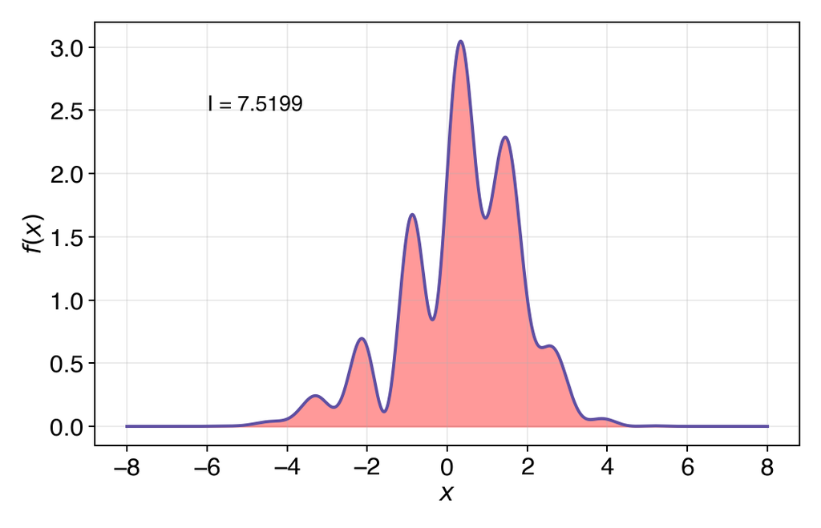

# Limitations of uniform sampling

- We can use uniformly distributed points $x_i$ and compute

  \begin{equation*} I = \int_a^b f(x) dx = \int_{-\infty}^\infty \pi(x) \frac{f(x)}{\pi(x)} dx \simeq \frac{1}{N} \sum_{i=1}^N \frac{f(x_i)}{\pi(x_i)} \qquad \pi(x) = \begin{cases} 1/(b-a) & \text{if} \quad a \le x \le b\\ 0 & \text{otherwise} \end{cases} \end{equation*}
- Is this a good strategy?
- The drawback is that many points sample useless areas

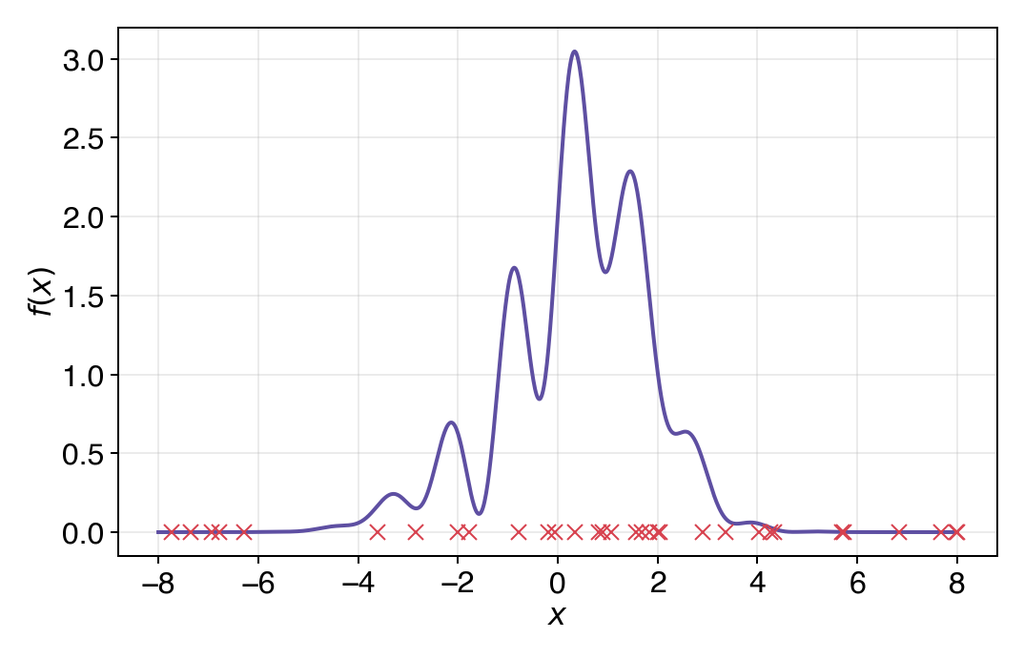

# Sampling with other distributions

- We are free to use other distributions $\pi$ to sample the points $x_i$

  \begin{equation*} I = \int_{-\infty}^\infty f(x) dx = \int_{-\infty}^\infty \pi(x) \frac{f(x)}{\pi(x)} dx \simeq \frac{1}{N} \sum_{i=1}^N \frac{f(x_i)}{\pi(x_i)} \end{equation*}
- It seems natural to use one that would favour areas where $f(x)$ is large
- Let's try with a normal distribution of width $\sigma$

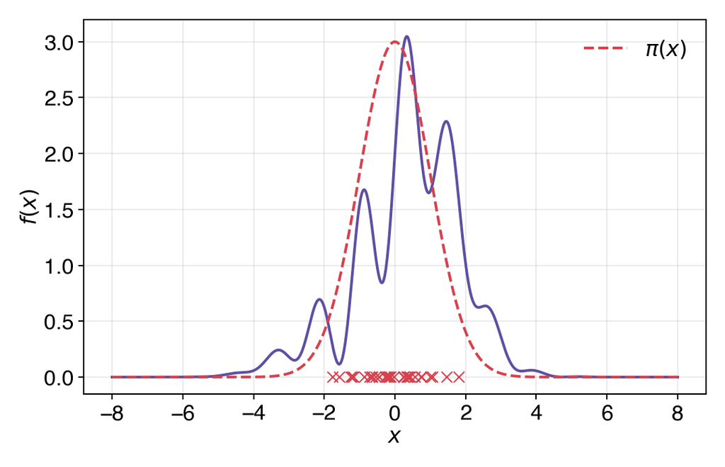

# Optimal importance sampling

- The width $\sigma$ of the normal distribution is a free parameter
- Let's see how different choices for $\sigma$ change the standard deviation

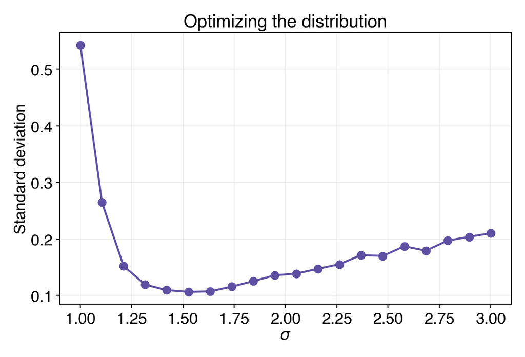

- For the optimal $\sigma$ the distribution best captures the areas where the function is large
- Ultimately we would want to have a distribution as close to $f(x)$ as possible

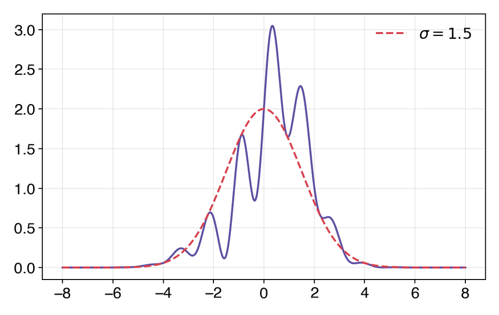

# Summary

- Importance sampling can be seen as a **variance reduction** technique.
- Better results are obtained when points are sampled according to a distribution that is close to the function $f(x)$.
- We need to be able to sample **arbitrary probability distributions**.

# Outline

- Introduction to Monte Carlo
- Newton–Cotes quadrature
- Importance sampling
- Direct sampling methods
- Markov chain sampling and balance condition
- Metropolis-Hastings algorithm
- The two-dimensional Ising model
- Error bar analysis
- References